# DAB501 Project #2

Kailash Baskar 0790883

### Academic Integrity

I Kailash Baskar, hereby state that I have not communicated with or gained information in any way from any person or resource that would violate the College’s academic integrity policies, and that all work presented is my own. In addition, I also agree not to share my work in any way, before or after submission, that would violate the College’s academic integrity policies.

### Data set

https://www.kaggle.com/ankitverma2010/ecommerce-customer-churn-analysis-and-prediction

#### Loading the data

Installing the required packages.

```r
install.packages("tidyverse", repos = "https://cran.rstudio.com")
library(tidyverse)
library(dplyr)
```

Loading the dataset.

```r
library(readxl)
E_Commerce_Dataset <- read_excel("C:\\Users\\Kailash Baskar\\Desktop\\R_DAB501\\DAB501\\Docs\\E_Comm\\E Commerce Dataset.xlsx", sheet = "E Comm")
View(E_Commerce_Dataset)

edata <- E_Commerce_Dataset
glimpse(edata)
```

```
## Rows: 5,630
## Columns: 20
## $ CustomerID                  <dbl> 50001, 50002, 50003, 50004, 50005, 50006, ~
## $ Churn                       <dbl> 1, 1, 1, 1, 1, 1, 1, 1, 1, 1, 1, 1, 1, 1, ~
## $ Tenure                      <dbl> 4, NA, NA, 0, 0, 0, NA, NA, 13, NA, 4, 11,~
## $ PreferredLoginDevice        <chr> "Mobile Phone", "Phone", "Phone", "Phone",~
## $ CityTier                    <dbl> 3, 1, 1, 3, 1, 1, 3, 1, 3, 1, 1, 1, 1, 1, ~
## $ WarehouseToHome             <dbl> 6, 8, 30, 15, 12, 22, 11, 6, 9, 31, 18, 6,~
## $ PreferredPaymentMode        <chr> "Debit Card", "UPI", "Debit Card", "Debit ~
## $ Gender                      <chr> "Female", "Male", "Male", "Male", "Male", ~
## $ HourSpendOnApp              <dbl> 3, 3, 2, 2, NA, 3, 2, 3, NA, 2, 2, 3, 2, 3~
## $ NumberOfDeviceRegistered    <dbl> 3, 4, 4, 4, 3, 5, 3, 3, 4, 5, 3, 4, 3, 4, ~
## $ PreferedOrderCat            <chr> "Laptop & Accessory", "Mobile", "Mobile", ~
## $ SatisfactionScore           <dbl> 2, 3, 3, 5, 5, 5, 2, 2, 3, 3, 3, 3, 3, 3, ~
## $ MaritalStatus               <chr> "Single", "Single", "Single", "Single", "S~
## $ NumberOfAddress             <dbl> 9, 7, 6, 8, 3, 2, 4, 3, 2, 2, 2, 10, 2, 1,~
## $ Complain                    <dbl> 1, 1, 1, 0, 0, 1, 0, 1, 1, 0, 0, 1, 1, 1, ~
## $ OrderAmountHikeFromlastYear <dbl> 11, 15, 14, 23, 11, 22, 14, 16, 14, 12, NA~
## $ CouponUsed                  <dbl> 1, 0, 0, 0, 1, 4, 0, 2, 0, 1, 9, 0, 2, 0, ~
## $ OrderCount                  <dbl> 1, 1, 1, 1, 1, 6, 1, 2, 1, 1, 15, 1, 2, 1,~
## $ DaySinceLastOrder           <dbl> 5, 0, 3, 3, 3, 7, 0, 0, 2, 1, 8, 0, 2, 0, ~
## $ CashbackAmount              <dbl> 159.93, 120.90, 120.28, 134.07, 129.60, 13~
```

### Univariant Analysis

#### Numeric Data

For the Numeric Univariant Analysis we take the variable “*CashbackAmount*” as our data.

Calculating **Mean** and **Median** for the variable.

```r
summary(edata$CashbackAmount)
```

```
##    Min. 1st Qu.  Median    Mean 3rd Qu.    Max.
##     0.0   145.8   163.3   177.2   196.4   325.0
```

```r
cash_mean = mean(edata$CashbackAmount)
cash_mean
```

```
## [1] 177.223
```

```r
cash_median = median(edata$CashbackAmount)
cash_median
```

```
## [1] 163.28
```

- *Create an appropriate plot to visualize the distribution of this variable.*

Visualizing the variable “*CashbackAmount*” distribution.

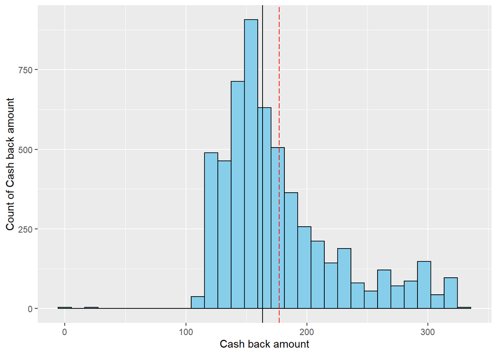

```r
ggplot(edata, aes(CashbackAmount)) + geom_histogram(binwidth = 11, color="black", fill="skyblue") + geom_vline(xintercept = cash_mean, linetype="longdash", color="red")  + geom_vline(xintercept = cash_median, color="black") + labs(x="Cash back amount", y="Count of Cash back amount")
```

- *Consider any outliers present in the data. If present, specify the criteria used to identify them and provide a logical explanation for how you handled them.*

Checking for possible outliers

```r
 t1 <- edata %>% filter(CashbackAmount <= 0)
 t1
```

| CustomerID | Churn | Tenure | PreferredLoginDevice | CityTier | WarehouseToHome | PreferredPaymentMode | Gender | HourSpendOnApp | NumberOfDeviceRegistered | PreferedOrderCat | SatisfactionScore | MaritalStatus | NumberOfAddress | Complain | OrderAmountHikeFromlastYear | CouponUsed | OrderCount | DaySinceLastOrder | CashbackAmount |
| --- | --- | --- | --- | --- | --- | --- | --- | --- | --- | --- | --- | --- | --- | --- | --- | --- | --- | --- | --- |
| 50102 | 0 | 10 | Computer | 3 | 10 | E wallet | Male | 2 | 3 | Mobile Phone | 2 | Married | 5 | 0 | 17 | 1 | 5 | 8 | 0 |
| 51027 | 0 | 1 | Mobile Phone | 1 | 33 | Credit Card | Female | 2 | 5 | Laptop & Accessory | 5 | Married | 1 | 0 | 21 | 1 | 1 | 0 | 0 |
| 51177 | 0 | 30 | Computer | 3 | 8 | Credit Card | Male | 2 | 3 | Grocery | 4 | Married | 5 | 0 | 22 | 10 | 14 | 14 | 0 |
| 51256 | 0 | 8 | Mobile Phone | 3 | 24 | Credit Card | Male | 3 | 3 | Laptop & Accessory | 5 | Married | 1 | 0 | 16 | 0 | 1 | 4 | 0 |

- *Describe the shape and skewness of the distribution.*

Shape and Skewness

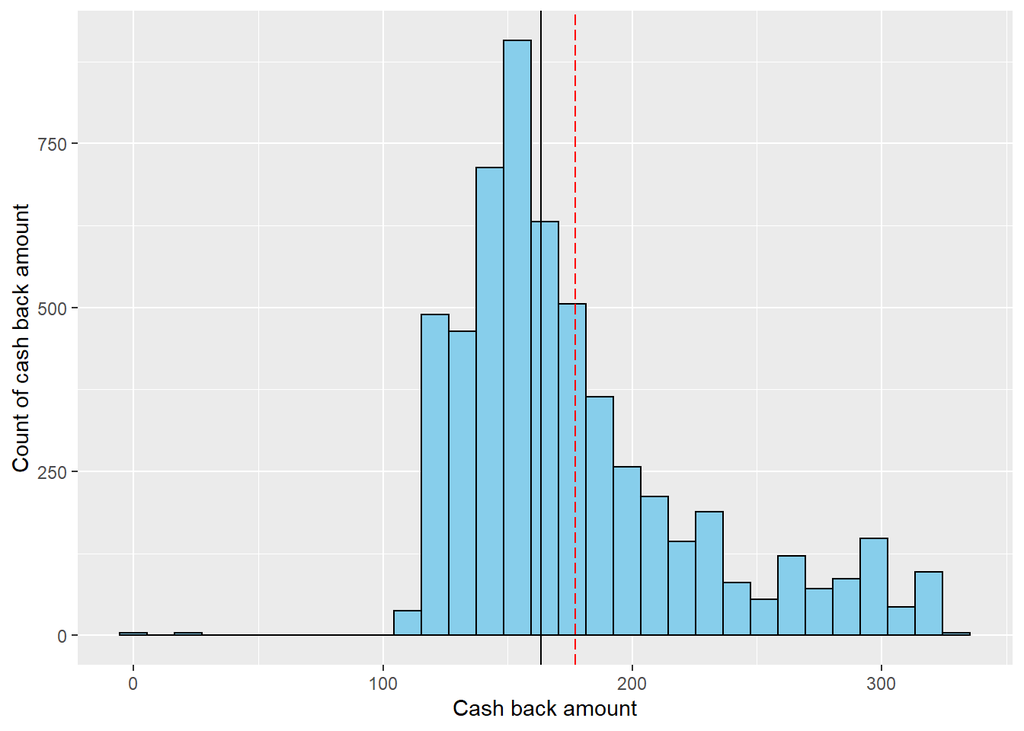

```r
ggplot(edata, aes(CashbackAmount)) + geom_histogram(binwidth = 11, color="black", fill="skyblue") + geom_vline(xintercept = cash_mean, linetype="longdash", color="red")  + geom_vline(xintercept = cash_median, color="black")  + labs(x="Cash back amount", y="Count of cash back amount")
```

```r
summary(edata$CashbackAmount)
```

```
##    Min. 1st Qu.  Median    Mean 3rd Qu.    Max.
##     0.0   145.8   163.3   177.2   196.4   325.0
```

On looking at the summary data and the plot looks like the data is right skewed and as it has few high bars and as it not uniform it looks slightly like a multimodel modality.

- *Based on your answer to the previous question, decide if it is appropriate to apply a transformation to your data. If no, explain why not. If yes, name the transformation applied and visualize the transformed distribution*

As the data is not extremely skewed, this data sample does not need any Transformation.

- *Choose and calculate an appropriate measure of central tendency*

- *Explain why you chose this as your measure of central tendency. Provide supporting evidence for your choice*

```r
summary(edata$CashbackAmount)
```

```
##    Min. 1st Qu.  Median    Mean 3rd Qu.    Max.
##     0.0   145.8   163.3   177.2   196.4   325.0
```

- *Choose and calculate a measure of spread that is appropriate for your chosen measure of central tendency. Explain why you chose this as your measure of spread.*

The spread of the variable is mainly towards the median area where most of the observations live within an Interquatile range of 50.

```r
summary(edata$CashbackAmount)
```

```
##    Min. 1st Qu.  Median    Mean 3rd Qu.    Max.
##     0.0   145.8   163.3   177.2   196.4   325.0
```

```r
IQR(edata$CashbackAmount)
```

```
## [1] 50.6225
```

#### Categorical variable

For this exercise we take the variable “*PreferedOrderCat*” as our data.

- *Create an appropriate plot to visualize the distribution of counts for this variable*

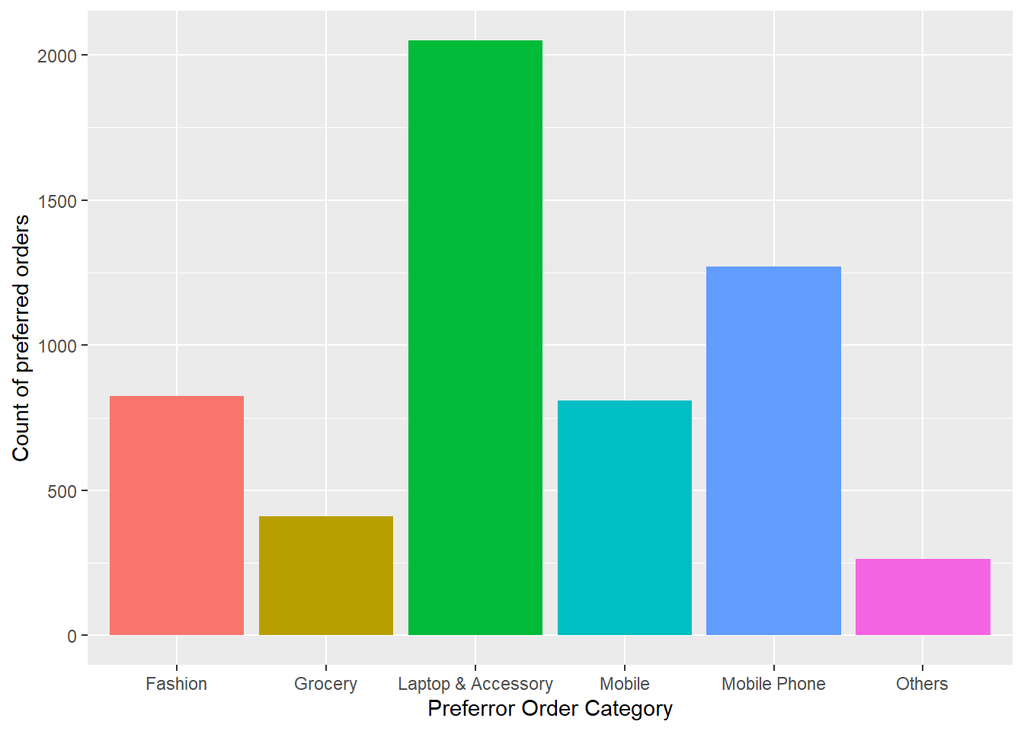

```r
ggplot(edata, aes(PreferedOrderCat)) + geom_bar(aes(fill=PreferedOrderCat), show.legend=FALSE) + labs(x="Preferror Order Category", y="Count of preferred orders")
```

- *Create an appropriate plot to visualize the distribution of proportions for this variable.*

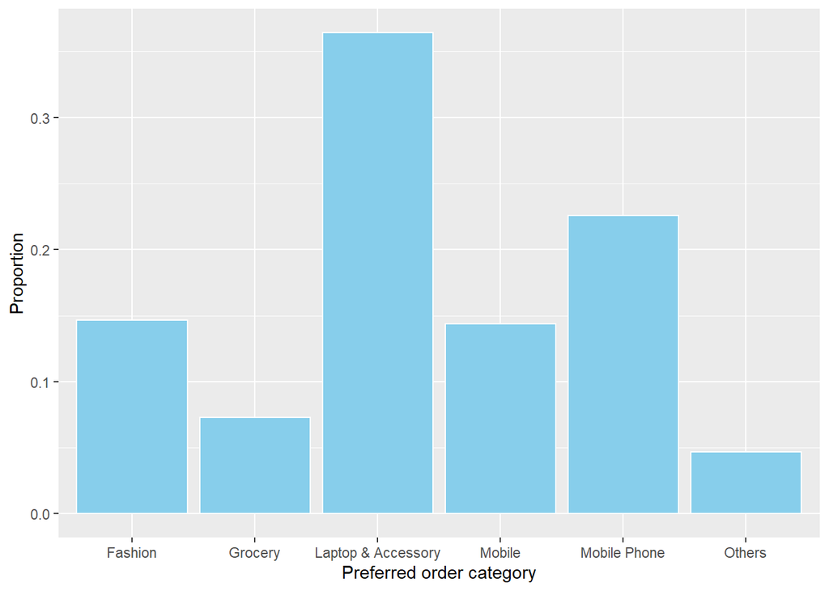

```r
ggplot(edata) + geom_bar(aes(PreferedOrderCat, y=..prop.., group=1), stat='count', fill="skyblue", color="white") + labs(x="Preferred order category", y="Proportion")
```

- *Discuss any unusual observations for this variable.*

There are no major unusual observation recorded for this variable.

```r
examine <- edata %>% select(PreferedOrderCat) %>% group_by(PreferedOrderCat) %>% summarise(count = n()) %>% mutate(prop = count / sum(count)) %>% mutate(percent_of_total = (count / sum(count) * 100 ))

examine
```

| PreferedOrderCat | count | prop | percent_of_total |
| --- | --- | --- | --- |
| Fashion | 826 | 0.14671403 | 14.671403 |
| Grocery | 410 | 0.07282416 | 7.282416 |
| Laptop & Accessory | 2050 | 0.36412078 | 36.412078 |
| Mobile | 809 | 0.14369449 | 14.369449 |
| Mobile Phone | 1271 | 0.22575488 | 22.575488 |
| Others | 264 | 0.04689165 | 4.689165 |

- *Discuss if there are too few/too many unique values.*

```r
unique(edata$PreferedOrderCat)
```

```
## [1] "Laptop & Accessory" "Mobile"             "Mobile Phone"
## [4] "Others"             "Fashion"            "Grocery"
```

In total there are 6 unique values available for this variable it is considered as a good number of unique value for this variable.

### Bivariate Analysis

Let’s select and clean the data.

Four this exercise the variables *MaritalStatus, CashbackAmount and Tenure* are selected.

```r
bi_c <- edata %>% select(MaritalStatus, CashbackAmount, Tenure) %>% drop_na(MaritalStatus, CashbackAmount, Tenure)
```

#### Two numerical data

- *Create an appropriate plot to visualize the relationship between the two variables.*

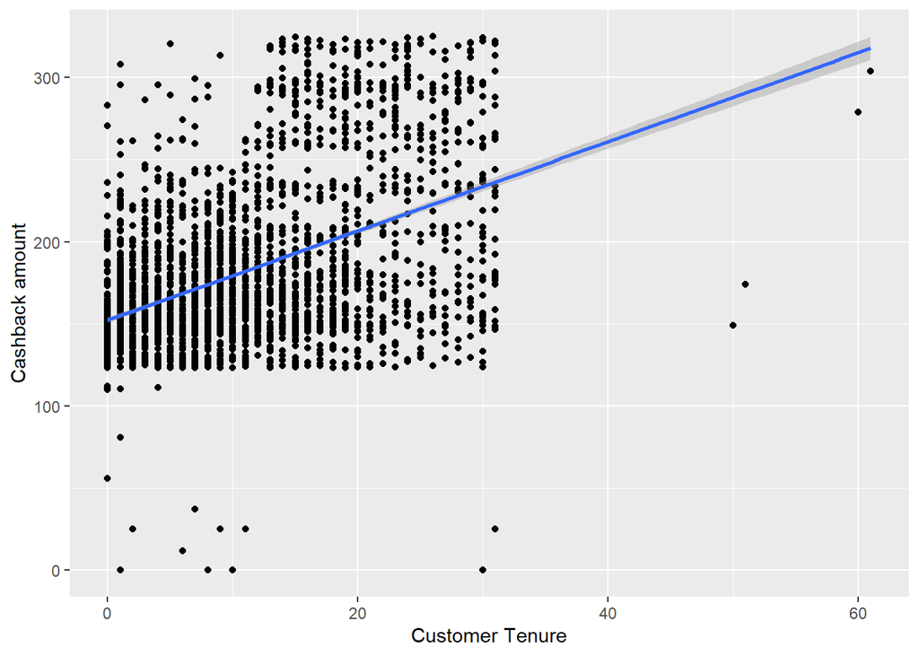

```r
ggplot(bi_c, aes(Tenure, CashbackAmount)) + geom_point() + geom_smooth(method="lm", formula = y ~ x) + labs(x="Customer Tenure", y="Cashback amount")
```

- *Describe the form, direction, and strength of the observed relationship. Include both qualitative and quantitative measures, as appropriate.*

The points have a positive trend and though there are few outliers, the points are not spread completely around the plot. Most observations stays close together and as most of the points in lower tenure period has closer observations than higher tenure the graph is moderately linear.

Clearing out outliers for better visualization

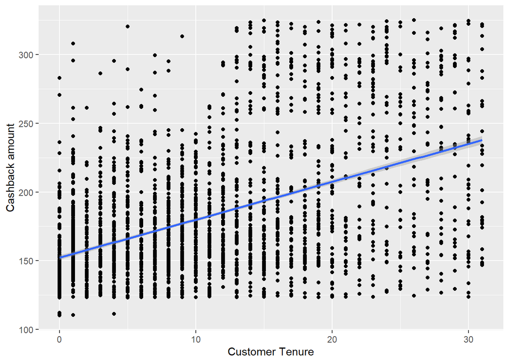

```r
bi_1 <- bi_c %>% select(CashbackAmount, Tenure) %>% filter(between(Tenure, 0, 40)) %>% filter(between(CashbackAmount, 100, 400))

ggplot(bi_1, aes(Tenure, CashbackAmount)) + geom_point() + geom_smooth(method="lm", formula= y ~ x) + labs(x="Customer Tenure", y="Cashback amount")
```

- *Explain what this relationship means in the context of the data*

As the customer Tenure increases the CashbackAmount claimed by the customer also increases.

- *Describe the variability that you observe in the plot and how that corresponds to the strength you calculated in #2 above.*

```r
mean(bi_c$Tenure)
```

```
## [1] 10.1899
```

```r
sd(bi_c$Tenure)
```

```
## [1] 8.557241
```

```r
mean(bi_c$CashbackAmount)
```

```
## [1] 180.015
```

```r
sd(bi_c$CashbackAmount)
```

```
## [1] 48.72242
```

```r
summary(bi_c$CashbackAmount)
```

```
##    Min. 1st Qu.  Median    Mean 3rd Qu.    Max.
##     0.0   147.7   165.4   180.0   199.5   325.0
```

```r
summary(bi_c$Tenure)
```

```
##    Min. 1st Qu.  Median    Mean 3rd Qu.    Max.
##    0.00    2.00    9.00   10.19   16.00   61.00
```

#### One Numeric and one categorical

- *Create an appropriate plot to visualize the relationship between the two variables.*

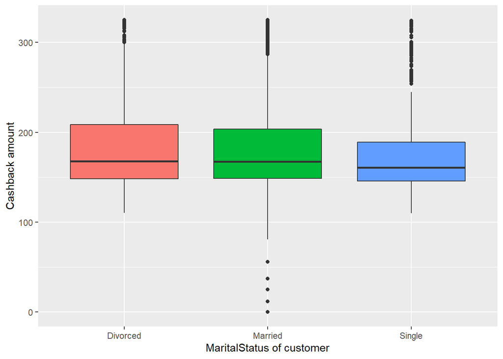

```r
ggplot(bi_c, aes(MaritalStatus, CashbackAmount)) + geom_boxplot(aes(fill=MaritalStatus), show.legend = FALSE) + labs(x="MaritalStatus of customer", y="Cashback amount")
```

- *Describe the form, direction, and strength of the observed relationship. Include both qualitative and quantitative measures, as appropriate.*

- *Explain what this relationship means in the context of the data*

From the plot and the context of data we could see that the Divorsed users had got the maximum average of cashback amount and also has the highest IQR of cashback among the other category of users.

- *Describe the variability that you observe in the plot and how that corresponds to the strength you calculated in #2 above.*

```r
tapply(bi_c$CashbackAmount, bi_c$MaritalStatus, mean)
```

```
## Divorced  Married   Single
## 185.2877 182.1564 173.8984
```

```r
tapply(bi_c$CashbackAmount, bi_c$MaritalStatus, sd)
```

```
## Divorced  Married   Single
## 51.69184 50.03167 44.25621
```

```r
tapply(bi_c$CashbackAmount, bi_c$MaritalStatus, IQR)
```

```
## Divorced  Married   Single
##  60.6800  55.2075  43.0700
```

The mean CashbackAmount for the Divorced peopleis higher when compared to the other two user category also the measure of spread is large on that user category.

Though the means for other user vary slightly they all lie around the middle of the IQR range and thus exhibit a strong relationship. Though single users has the lease when compared to others two category they have the closest measure of spread when compared to other two user category.

### References

https://www.westga.edu/academics/research/vrc/assets/docs/scatterplots_and_correlation_notes.pdf

https://lms.stclaircollege.ca/bbcswebdav/pid-2273873-dt-content-rid-26842374_1/courses/DAB501-21F-001002003004/R4DS_Chapter_7b_soln.html

https://lms.stclaircollege.ca/webapps/blackboard/execute/content/file?cmd=view&content_id=_2263843_1&course_id=_49673_1

https://runestone.academy/runestone/books/published/ac1/scatter_plots_and_correlation/describing_scatter_plots.html